# Mini Project 2 — Unsupervised Learning

## Consumer Behaviour & Shopping Habits Analysis

**Student ID:** 2025AIML060  
**Dataset:** Shopping Trends and Customer Behaviour Dataset (Kaggle)

This project explores customer shopping patterns using unsupervised learning techniques — specifically clustering algorithms — alongside descriptive analysis to uncover meaningful insights from the dataset.

## Part 1 — Data Preprocessing

### 1.1 Importing Libraries

```python
# Standard libraries
import numpy as np
import pandas as pd
import warnings
warnings.filterwarnings('ignore')

# Visualization
import matplotlib.pyplot as plt
import seaborn as sns
plt.rcParams['figure.figsize'] = (10, 6)
plt.rcParams['axes.grid'] = True

# Preprocessing & Metrics
from sklearn.preprocessing import StandardScaler, LabelEncoder
from sklearn.decomposition import PCA
from sklearn.metrics import silhouette_score

# Clustering
from sklearn.cluster import KMeans, AgglomerativeClustering, DBSCAN
from scipy.cluster.hierarchy import dendrogram, linkage

print("All libraries loaded successfully.")
```

```
All libraries loaded successfully.
```

### 1.2 Loading the Dataset

```python
# Loading dataset from local CSV file
df_raw = pd.read_csv('Shopping Trends And Customer Behaviour Dataset.csv')

print(f"Dataset shape: {df_raw.shape}")
print(f"\nColumn names:\n{list(df_raw.columns)}")
df_raw.head(5)
```

```
Dataset shape: (3900, 18)

Column names:
['Unnamed: 0', 'Customer ID', 'Age', 'Gender', 'Item Purchased', 'Category', 'Purchase Amount (USD)', 'Location', 'Color', 'Season', 'Review Rating', 'Subscription Status', 'Shipping Type', 'Discount Applied', 'Promo Code Used', 'Previous Purchases', 'Payment Method', 'Frequency of Purchases']
```

|  | Unnamed: 0 | Customer ID | Age | Gender | Item Purchased | Category | Purchase Amount (USD) | Location | Color | Season | Review Rating | Subscription Status | Shipping Type | Discount Applied | Promo Code Used | Previous Purchases | Payment Method | Frequency of Purchases |
| --- | --- | --- | --- | --- | --- | --- | --- | --- | --- | --- | --- | --- | --- | --- | --- | --- | --- | --- |
| 0 | 0 | 1 | 55 | Male | Blouse | Clothing | 53 | Kentucky | Gray | Winter | 3.1 | Yes | Express | Yes | Yes | 14 | Venmo | Fortnightly |
| 1 | 1 | 2 | 19 | Male | Sweater | Clothing | 64 | Maine | Maroon | Winter | 3.1 | Yes | Express | Yes | Yes | 2 | Cash | Fortnightly |
| 2 | 2 | 3 | 50 | Male | Jeans | Clothing | 73 | Massachusetts | Maroon | Spring | 3.1 | Yes | Free Shipping | Yes | Yes | 23 | Credit Card | Weekly |
| 3 | 3 | 4 | 21 | Male | Sandals | Footwear | 90 | Rhode Island | Maroon | Spring | 3.5 | Yes | Next Day Air | Yes | Yes | 49 | PayPal | Weekly |
| 4 | 4 | 5 | 45 | Male | Blouse | Clothing | 49 | Oregon | Turquoise | Spring | 2.7 | Yes | Free Shipping | Yes | Yes | 31 | PayPal | Annually |

### 1.3 Basic Dataset Statistics

```python
# Statistical summary — gives a feel for numeric distributions
print("--- Descriptive Statistics ---")
display(df_raw.describe())

print("\n--- Data Types ---")
print(df_raw.dtypes)
```

```
--- Descriptive Statistics ---
```

|  | Unnamed: 0 | Customer ID | Age | Purchase Amount (USD) | Review Rating | Previous Purchases |
| --- | --- | --- | --- | --- | --- | --- |
| count | 3900.000000 | 3900.000000 | 3900.000000 | 3900.000000 | 3900.000000 | 3900.000000 |
| mean | 1949.500000 | 1950.500000 | 44.068462 | 59.764359 | 3.749949 | 25.351538 |
| std | 1125.977353 | 1125.977353 | 15.207589 | 23.685392 | 0.716223 | 14.447125 |
| min | 0.000000 | 1.000000 | 18.000000 | 20.000000 | 2.500000 | 1.000000 |
| 25% | 974.750000 | 975.750000 | 31.000000 | 39.000000 | 3.100000 | 13.000000 |
| 50% | 1949.500000 | 1950.500000 | 44.000000 | 60.000000 | 3.700000 | 25.000000 |
| 75% | 2924.250000 | 2925.250000 | 57.000000 | 81.000000 | 4.400000 | 38.000000 |
| max | 3899.000000 | 3900.000000 | 70.000000 | 100.000000 | 5.000000 | 50.000000 |

```
--- Data Types ---
Unnamed: 0                  int64
Customer ID                 int64
Age                         int64
Gender                     object
Item Purchased             object
Category                   object
Purchase Amount (USD)       int64
Location                   object
Color                      object
Season                     object
Review Rating             float64
Subscription Status        object
Shipping Type              object
Discount Applied           object
Promo Code Used            object
Previous Purchases          int64
Payment Method             object
Frequency of Purchases     object
dtype: object
```

### 1.4 Handling Missing Values & Duplicates

```python
# Check for missing values across all columns
missing_summary = df_raw.isnull().sum()
print("Missing values per column:")
print(missing_summary[missing_summary > 0] if missing_summary.any() else "No missing values found!")

# Check and remove duplicate records
dup_count = df_raw.duplicated().sum()
print(f"\nDuplicate rows found: {dup_count}")

df_clean = df_raw.drop_duplicates().reset_index(drop=True)
print(f"Shape after deduplication: {df_clean.shape}")
```

```
Missing values per column:
No missing values found!

Duplicate rows found: 0
Shape after deduplication: (3900, 18)
```

### 1.5 Outlier Detection & Removal using IQR

I am using the Interquartile Range (IQR) method to identify and remove outliers in numeric columns. Any value below Q1 - 1.5×IQR or above Q3 + 1.5×IQR is treated as an outlier.

```
Numeric columns: ['Unnamed: 0', 'Customer ID', 'Age', 'Purchase Amount (USD)', 'Review Rating', 'Previous Purchases']
```

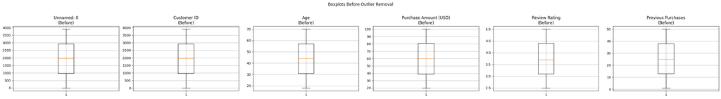

```
Shape before outlier removal: (3900, 18)
Shape after outlier removal:  (3900, 18)
```

```python
# Select only numeric columns for outlier analysis
num_cols = df_clean.select_dtypes(include=['int64', 'float64']).columns.tolist()
print(f"Numeric columns: {num_cols}")

# Visualize distribution before outlier removal
fig, axes = plt.subplots(1, len(num_cols), figsize=(5 * len(num_cols), 4))
if len(num_cols) == 1:
    axes = [axes]
for ax, col in zip(axes, num_cols):
    ax.boxplot(df_clean[col].dropna())
    ax.set_title(f'{col}\n(Before)')
plt.suptitle('Boxplots Before Outlier Removal', y=1.02)
plt.tight_layout()
plt.show()

# IQR-based removal
df_filtered = df_clean.copy()
for col in num_cols:
    q1 = df_filtered[col].quantile(0.25)
    q3 = df_filtered[col].quantile(0.75)
    iqr_val = q3 - q1
    lower_bound = q1 - 1.5 * iqr_val
    upper_bound = q3 + 1.5 * iqr_val
    df_filtered = df_filtered[(df_filtered[col] >= lower_bound) & (df_filtered[col] <= upper_bound)]

df_filtered = df_filtered.reset_index(drop=True)
print(f"\nShape before outlier removal: {df_clean.shape}")
print(f"Shape after outlier removal:  {df_filtered.shape}")
```

### 1.6 Feature Engineering & Encoding

Categorical columns are encoded using `LabelEncoder` so they can participate in clustering.

```python
df_encoded = df_filtered.copy()

cat_columns = df_encoded.select_dtypes(include=['object']).columns.tolist()
print(f"Categorical columns to encode: {cat_columns}")

encoder = LabelEncoder()
for c in cat_columns:
    df_encoded[c] = encoder.fit_transform(df_encoded[c].astype(str))

print("\nEncoding completed. Sample:")
df_encoded.head(3)
```

```
Categorical columns to encode: ['Gender', 'Item Purchased', 'Category', 'Location', 'Color', 'Season', 'Subscription Status', 'Shipping Type', 'Discount Applied', 'Promo Code Used', 'Payment Method', 'Frequency of Purchases']

Encoding completed. Sample:
```

|  | Unnamed: 0 | Customer ID | Age | Gender | Item Purchased | Category | Purchase Amount (USD) | Location | Color | Season | Review Rating | Subscription Status | Shipping Type | Discount Applied | Promo Code Used | Previous Purchases | Payment Method | Frequency of Purchases |
| --- | --- | --- | --- | --- | --- | --- | --- | --- | --- | --- | --- | --- | --- | --- | --- | --- | --- | --- |
| 0 | 0 | 1 | 55 | 1 | 2 | 1 | 53 | 16 | 7 | 3 | 3.1 | 1 | 1 | 1 | 1 | 14 | 5 | 3 |
| 1 | 1 | 2 | 19 | 1 | 23 | 1 | 64 | 18 | 12 | 3 | 3.1 | 1 | 1 | 1 | 1 | 2 | 1 | 3 |
| 2 | 2 | 3 | 50 | 1 | 11 | 1 | 73 | 20 | 12 | 1 | 3.1 | 1 | 2 | 1 | 1 | 23 | 2 | 6 |

### 1.7 Feature Scaling using StandardScaler

Distance-based algorithms like K-Means and DBSCAN are sensitive to scale. Standardisation ensures each feature contributes equally.

```python
scaler_obj = StandardScaler()
X_scaled = scaler_obj.fit_transform(df_encoded)
df_scaled = pd.DataFrame(X_scaled, columns=df_encoded.columns)

print("Feature matrix after scaling — sample rows:")
print(df_scaled.head(3))
print(f"\nFeature matrix shape: {df_scaled.shape}")
```

```
Feature matrix after scaling — sample rows:
   Unnamed: 0  Customer ID       Age    Gender  Item Purchased  Category  \
0   -1.731607    -1.731607  0.718913  0.685994       -1.394144 -0.002002
1   -1.730719    -1.730719 -1.648629  0.685994        1.523236 -0.002002
2   -1.729830    -1.729830  0.390088  0.685994       -0.143839 -0.002002

   Purchase Amount (USD)  Location     Color    Season  Review Rating  \
0              -0.285629 -0.576399 -0.707620  1.349198      -0.907584
1               0.178852 -0.436944 -0.015163  1.349198      -0.907584
2               0.558882 -0.297488 -0.015163 -0.441163      -0.907584

   Subscription Status  Shipping Type  Discount Applied  Promo Code Used  \
0             1.644294      -0.892178          1.151339         1.151339
1             1.644294      -0.892178          1.151339         1.151339
2             1.644294      -0.303032          1.151339         1.151339

   Previous Purchases  Payment Method  Frequency of Purchases
0           -0.785831        1.471636                0.012575
1           -1.616552       -0.894631                0.012575
2           -0.162789       -0.303064                1.513849

Feature matrix shape: (3900, 18)
```

### 1.8 Dimensionality Reduction for Visualisation (PCA → 2D)

Since the feature space is multi-dimensional, I reduce it to 2 principal components purely for visualisation purposes.

```
Explained variance by 2 PCs: 33.30%
```

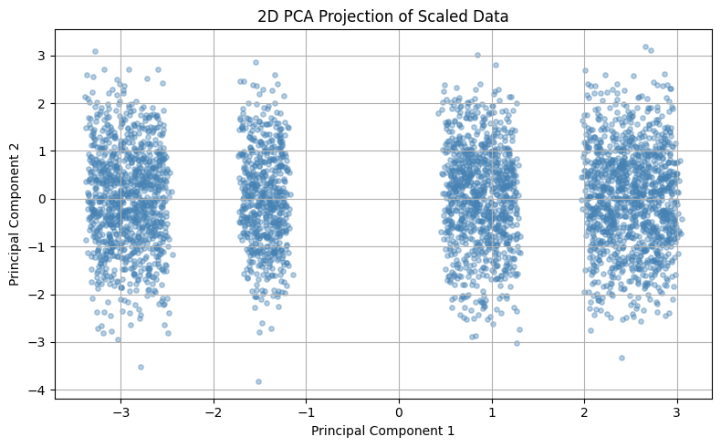

```python
pca2 = PCA(n_components=2, random_state=42)
X_2d = pca2.fit_transform(X_scaled)

print(f"Explained variance by 2 PCs: {pca2.explained_variance_ratio_.sum():.2%}")

plt.figure(figsize=(8, 5))
plt.scatter(X_2d[:, 0], X_2d[:, 1], alpha=0.4, s=15, color='steelblue')
plt.title('2D PCA Projection of Scaled Data')
plt.xlabel('Principal Component 1')
plt.ylabel('Principal Component 2')
plt.tight_layout()
plt.show()
```

## Part 2 — Customer Segmentation using Clustering

### 2.1 Elbow Method — Finding Optimal k for K-Means

I compute the within-cluster sum of squares (WCSS / inertia) for k = 1 to 12 and look for the "elbow" in the plot. The point of inflection suggests the natural number of clusters.

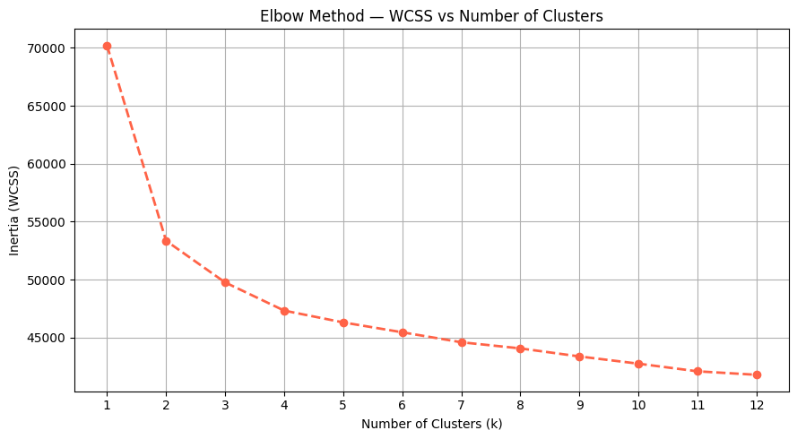

```
From the elbow curve, k=4 appears to be the optimal choice as the rate of inertia decrease flattens around that point.
```

```python
inertia_values = []
k_range = range(1, 13)

for k in k_range:
    km = KMeans(n_clusters=k, init='k-means++', n_init=10, random_state=7)
    km.fit(X_scaled)
    inertia_values.append(km.inertia_)

plt.figure(figsize=(9, 5))
plt.plot(list(k_range), inertia_values, marker='o', linestyle='--', color='tomato', linewidth=2)
plt.title('Elbow Method — WCSS vs Number of Clusters')
plt.xlabel('Number of Clusters (k)')
plt.ylabel('Inertia (WCSS)')
plt.xticks(list(k_range))
plt.tight_layout()
plt.show()

print("From the elbow curve, k=4 appears to be the optimal choice as the rate of inertia decrease flattens around that point.")
```

### 2.2 K-Means Clustering

I apply K-Means with the elbow-determined number of clusters (`k=4`) using `k-means++` initialisation for better convergence.

```
K-Means Silhouette Score (k=4): 0.1155

Cluster distribution:
  Cluster 0: 1053 customers
  Cluster 1: 1248 customers
  Cluster 2: 975 customers
  Cluster 3: 624 customers
```

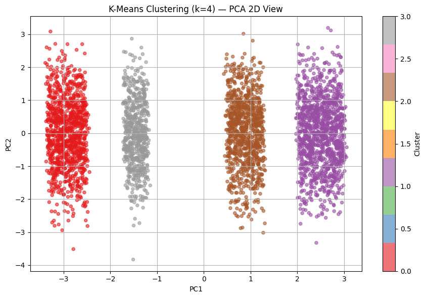

```python
best_k = 4  # chosen from the elbow plot

kmeans_model = KMeans(n_clusters=best_k, init='k-means++', n_init=10, random_state=7)
kmeans_labels = kmeans_model.fit_predict(X_scaled)

# Silhouette score for K-Means
sil_kmeans = silhouette_score(X_scaled, kmeans_labels)
print(f"K-Means Silhouette Score (k={best_k}): {sil_kmeans:.4f}")

# Count of records in each cluster
unique, counts = np.unique(kmeans_labels, return_counts=True)
print("\nCluster distribution:")
for u, c in zip(unique, counts):
    print(f"  Cluster {u}: {c} customers")

# 2D visualisation
plt.figure(figsize=(9, 6))
scatter = plt.scatter(X_2d[:, 0], X_2d[:, 1], c=kmeans_labels, cmap='Set1', s=20, alpha=0.6)
plt.colorbar(scatter, label='Cluster')
plt.title(f'K-Means Clustering (k={best_k}) — PCA 2D View')
plt.xlabel('PC1')
plt.ylabel('PC2')
plt.tight_layout()
plt.show()
```

### 2.3 Hierarchical (Agglomerative) Clustering

I use Ward's linkage method which minimises the total within-cluster variance at each merge step.

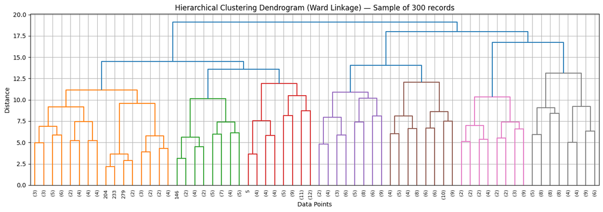

```
Agglomerative Clustering Silhouette Score (k=4): 0.1021
```

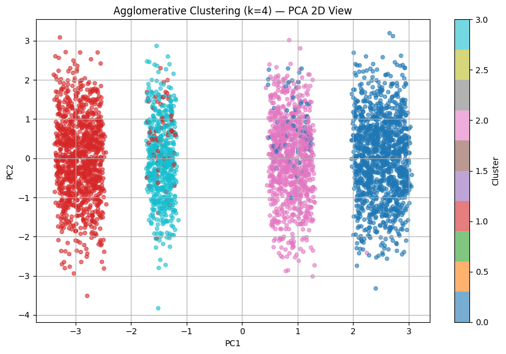

```python
# Dendrogram on a sample to keep computation feasible
sample_size = min(300, len(X_scaled))
X_sample = X_scaled[:sample_size]

linkage_matrix = linkage(X_sample, method='ward')

plt.figure(figsize=(14, 5))
dendrogram(linkage_matrix, truncate_mode='level', p=5, leaf_font_size=8)
plt.title('Hierarchical Clustering Dendrogram (Ward Linkage) — Sample of 300 records')
plt.xlabel('Data Points')
plt.ylabel('Distance')
plt.tight_layout()
plt.show()

# Full dataset clustering
agglo_model = AgglomerativeClustering(n_clusters=best_k, linkage='ward')
agglo_labels = agglo_model.fit_predict(X_scaled)

sil_agglo = silhouette_score(X_scaled, agglo_labels)
print(f"Agglomerative Clustering Silhouette Score (k={best_k}): {sil_agglo:.4f}")

plt.figure(figsize=(9, 6))
scatter2 = plt.scatter(X_2d[:, 0], X_2d[:, 1], c=agglo_labels, cmap='tab10', s=20, alpha=0.6)
plt.colorbar(scatter2, label='Cluster')
plt.title(f'Agglomerative Clustering (k={best_k}) — PCA 2D View')
plt.xlabel('PC1')
plt.ylabel('PC2')
plt.tight_layout()
plt.show()
```

### 2.4 DBSCAN Clustering

DBSCAN is a density-based method that does not require specifying k in advance and can detect noise points (label = -1). I use `eps=0.8` and `min_samples=5` as starting parameters.

```
DBSCAN found 0 clusters
Noise points (label=-1): 3900
Silhouette score not applicable (only 1 cluster or all noise).
```

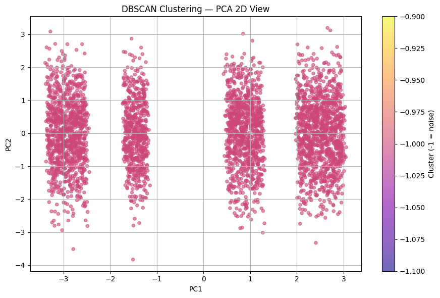

```python
dbscan_model = DBSCAN(eps=0.8, min_samples=5, metric='euclidean')
dbscan_labels = dbscan_model.fit_predict(X_scaled)

n_clusters_dbscan = len(set(dbscan_labels)) - (1 if -1 in dbscan_labels else 0)
noise_pts = np.sum(dbscan_labels == -1)

print(f"DBSCAN found {n_clusters_dbscan} clusters")
print(f"Noise points (label=-1): {noise_pts}")

# Silhouette score — only valid when more than 1 cluster
mask_non_noise = dbscan_labels != -1
if n_clusters_dbscan > 1 and mask_non_noise.sum() > 1:
    sil_dbscan = silhouette_score(X_scaled[mask_non_noise], dbscan_labels[mask_non_noise])
    print(f"DBSCAN Silhouette Score (excluding noise): {sil_dbscan:.4f}")
else:
    sil_dbscan = None
    print("Silhouette score not applicable (only 1 cluster or all noise).")

plt.figure(figsize=(9, 6))
scatter3 = plt.scatter(X_2d[:, 0], X_2d[:, 1], c=dbscan_labels, cmap='plasma', s=20, alpha=0.6)
plt.colorbar(scatter3, label='Cluster (-1 = noise)')
plt.title('DBSCAN Clustering — PCA 2D View')
plt.xlabel('PC1')
plt.ylabel('PC2')
plt.tight_layout()
plt.show()
```

### 2.5 Silhouette Score Comparison

A higher silhouette score (closer to 1) means better-defined, well-separated clusters.

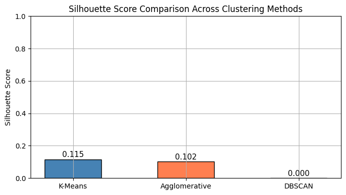

```
Best performing method based on Silhouette Score: K-Means
```

```python
methods = ['K-Means', 'Agglomerative', 'DBSCAN']
scores = [sil_kmeans, sil_agglo, sil_dbscan if sil_dbscan is not None else 0]

plt.figure(figsize=(7, 4))
bars = plt.bar(methods, scores, color=['steelblue', 'coral', 'mediumpurple'], edgecolor='black', width=0.5)
for bar, val in zip(bars, scores):
    plt.text(bar.get_x() + bar.get_width() / 2, bar.get_height() + 0.005, f'{val:.3f}', ha='center', va='bottom', fontsize=11)
plt.title('Silhouette Score Comparison Across Clustering Methods')
plt.ylabel('Silhouette Score')
plt.ylim(0, 1)
plt.tight_layout()
plt.show()

best_method = methods[np.argmax(scores)]
print(f"Best performing method based on Silhouette Score: {best_method}")
```

## Part 3 — Shopping Pattern Analysis

### 3.1 Most Preferred Payment Method

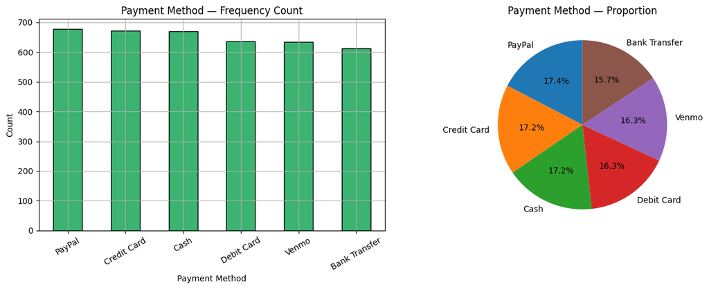

```
Most preferred payment method: 'PayPal' with 677 customers (17.4%)
```

```python
# Using the cleaned (pre-encoding) dataframe for interpretability
payment_col = 'Payment Method'

if payment_col in df_filtered.columns:
    payment_counts = df_filtered[payment_col].value_counts()

    fig, axes = plt.subplots(1, 2, figsize=(13, 5))

    # Bar chart
    payment_counts.plot(kind='bar', ax=axes[0], color='mediumseagreen', edgecolor='black')
    axes[0].set_title('Payment Method — Frequency Count')
    axes[0].set_xlabel('Payment Method')
    axes[0].set_ylabel('Count')
    axes[0].tick_params(axis='x', rotation=30)

    # Pie chart
    axes[1].pie(payment_counts, labels=payment_counts.index, autopct='%1.1f%%', startangle=90)
    axes[1].set_title('Payment Method — Proportion')

    plt.tight_layout()
    plt.show()

    top_payment = payment_counts.idxmax()
    print(f"Most preferred payment method: '{top_payment}' with {payment_counts.max()} customers ({payment_counts.max()/payment_counts.sum()*100:.1f}%)")
else:
    print(f"Column '{payment_col}' not found. Available columns:", list(df_filtered.columns))
```

### 3.2 Most Frequently Purchased Category by Gender

```
Overall Category Purchase Frequency:
Category
Clothing       1737
Accessories    1240
Footwear        599
Outerwear       324

Most frequently purchased category overall: 'Clothing'
```

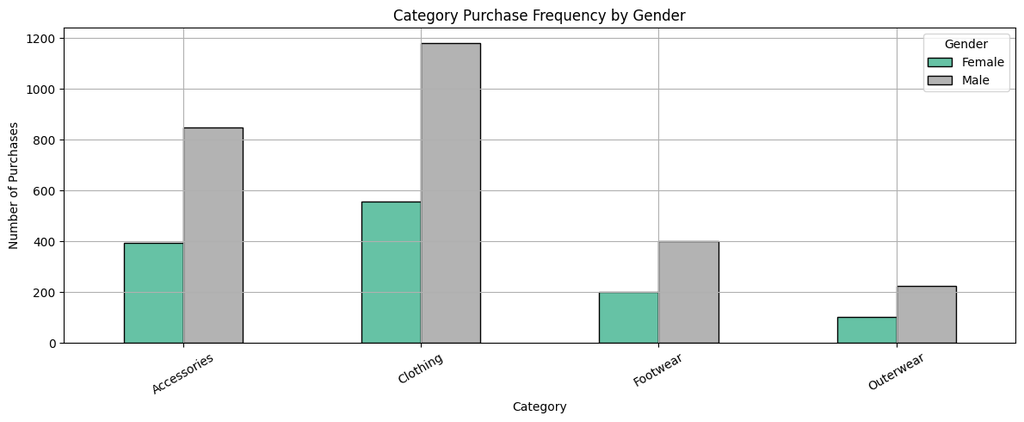

```
Top category by gender:
  Female: Clothing
  Male: Clothing
```

```python
cat_col = 'Category'
gender_col = 'Gender'

if cat_col in df_filtered.columns and gender_col in df_filtered.columns:
    # Overall most purchased category
    overall_cat = df_filtered[cat_col].value_counts()
    print("Overall Category Purchase Frequency:")
    print(overall_cat.to_string())
    print(f"\nMost frequently purchased category overall: '{overall_cat.idxmax()}'")

    # By gender breakdown
    cat_by_gender = df_filtered.groupby(gender_col)[cat_col].value_counts().unstack(fill_value=0)

    cat_by_gender.T.plot(kind='bar', figsize=(12, 5), colormap='Set2', edgecolor='black')
    plt.title('Category Purchase Frequency by Gender')
    plt.xlabel('Category')
    plt.ylabel('Number of Purchases')
    plt.xticks(rotation=30)
    plt.legend(title='Gender')
    plt.tight_layout()
    plt.show()

    print("\nTop category by gender:")
    for g in cat_by_gender.index:
        top = cat_by_gender.loc[g].idxmax()
        print(f"  {g}: {top}")
else:
    print("Required column(s) not found. Columns available:", list(df_filtered.columns))
```

### 3.3 Difference in Review Ratings Between Male and Female Customers

```
Review Rating Statistics by Gender:
         count   mean    std  min  25%  50%  75%  max
Gender
Female  1248.0  3.741  0.721  2.5  3.1  3.7  4.3  5.0
Male    2652.0  3.754  0.714  2.5  3.1  3.8  4.4  5.0
```

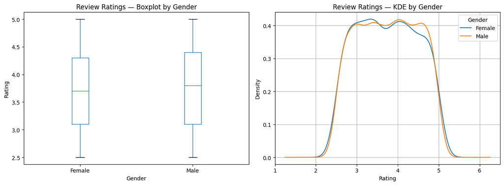

[output not shown]

```python
rating_col = 'Review Rating'

if rating_col in df_filtered.columns and gender_col in df_filtered.columns:
    ratings_by_gender = df_filtered.groupby(gender_col)[rating_col].describe()
    print("Review Rating Statistics by Gender:")
    print(ratings_by_gender.round(3))

    fig, axes = plt.subplots(1, 2, figsize=(13, 5))

    # Box plot
    df_filtered.boxplot(column=rating_col, by=gender_col, ax=axes[0], grid=False)
    axes[0].set_title('Review Ratings — Boxplot by Gender')
    axes[0].set_xlabel('Gender')
    axes[0].set_ylabel('Rating')
    plt.suptitle('')

    # KDE plot
    for g, grp in df_filtered.groupby(gender_col):
        grp[rating_col].plot(kind='kde', ax=axes[1], label=g)
    axes[1].set_title('Review Ratings — KDE by Gender')
    axes[1].set_xlabel('Rating')
    axes[1].legend(title='Gender')

    plt.tight_layout()
    plt.show()

    mean_diff = ratings_by_gender['mean'].diff().dropna()
    print(f"\nMean rating difference (Female - Male): {mean_diff.values[0]:.4f}")
    print("Observation: The difference in average review ratings between genders is relatively small, suggesting similar satisfaction levels.")
else:
    print("Required columns not found. Available:", list(df_filtered.columns))
```

### 3.4 State-wise Purchase Amount Analysis

```
State with lowest average purchase amount: Connecticut ($54.18)
State with highest average purchase amount: Alaska ($67.60)
```

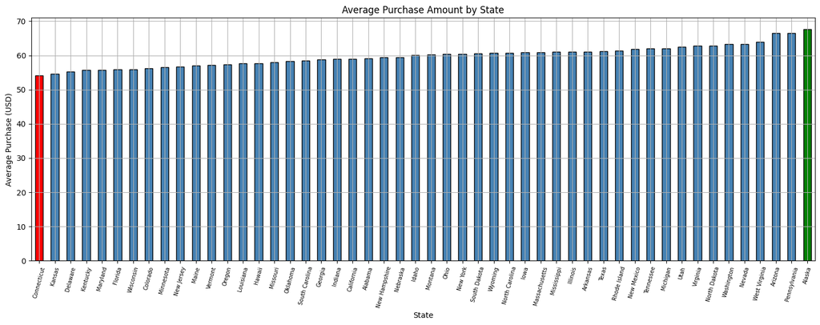

```python
location_col = 'Location'
purchase_col = 'Purchase Amount (USD)'

if location_col in df_filtered.columns and purchase_col in df_filtered.columns:
    state_avg_purchase = df_filtered.groupby(location_col)[purchase_col].mean().sort_values()

    lowest_state = state_avg_purchase.idxmin()
    highest_state = state_avg_purchase.idxmax()

    print(f"State with lowest average purchase amount: {lowest_state} (${state_avg_purchase.min():.2f})")
    print(f"State with highest average purchase amount: {highest_state} (${state_avg_purchase.max():.2f})")

    plt.figure(figsize=(15, 6))
    colors = ['red' if s == lowest_state else 'green' if s == highest_state else 'steelblue'
              for s in state_avg_purchase.index]
    state_avg_purchase.plot(kind='bar', color=colors, edgecolor='black')
    plt.title('Average Purchase Amount by State')
    plt.xlabel('State')
    plt.ylabel('Average Purchase (USD)')
    plt.xticks(rotation=75, fontsize=7)
    plt.tight_layout()
    plt.show()
else:
    print("Required columns not found. Available:", list(df_filtered.columns))
```

### 3.5 How Many Customer Segments Can Be Distinguished?

```python
# The K-Means elbow analysis indicated k=4 as optimal
# Let us look at the mean profile of each cluster to characterise them

df_filtered_copy = df_filtered.copy()
df_filtered_copy['KMeans_Cluster'] = kmeans_labels[:len(df_filtered_copy)]

cluster_profiles = df_filtered_copy.groupby('KMeans_Cluster')[num_cols + [purchase_col] if purchase_col in df_filtered_copy.columns else num_cols].mean().round(2)

print(f"\nBased on the Elbow method and K-Means, {best_k} distinct customer segments are identified:")
print(cluster_profiles)

print("\nSegment Summary:")
for i in range(best_k):
    count_i = np.sum(kmeans_labels == i)
    print(f"  Segment {i}: {count_i} customers")
```

```
Based on the Elbow method and K-Means, 4 distinct customer segments are identified:
                Unnamed: 0  Customer ID    Age  Purchase Amount (USD)  \
KMeans_Cluster
0                    526.0        527.0  44.23                  59.49
1                   3275.5       3276.5  44.01                  60.25
2                   2164.0       2165.0  44.02                  59.98
3                   1364.5       1365.5  44.00                  58.92

                Review Rating  Previous Purchases  Purchase Amount (USD)
KMeans_Cluster
0                        3.74               26.08                  59.49
1                        3.74               24.60                  60.25
2                        3.78               25.65                  59.98
3                        3.73               25.17                  58.92

Segment Summary:
  Segment 0: 1053 customers
  Segment 1: 1248 customers
  Segment 2: 975 customers
  Segment 3: 624 customers
```

## Conclusion

This project applied unsupervised learning techniques to the Consumer Behaviour & Shopping Habits dataset to extract meaningful patterns.

Together, the clustering and descriptive analyses provide a data-driven foundation for targeted marketing, inventory optimisation, and personalised recommendation strategies.